# Day One NCEAS Assignment-Becca

Rebecca Cates

11/4/2019

# Introduction

This data set explores crab abundance and size distribution along a sea otter gradient in SE Alaska for the years 2017, 2018, 2019. Multiple sites were sampled along the west coast of Prince of Wales island varying in sea otter density. In 2017, 21 sites were sampled, 6 in 2018 and 22 in 2019. At these sites, 4 strings with 1 fukui pot and one crab pot were attached to a line with a buoy and placed in ~15 ft of water at MLLW in eelgrass beds. Pots were soaked for 24 hrs and then pulled up. Crab species were identified, sexed and carapace width was measured (mm).

A link to the APECS Lab home page explaining the different projects of this lab can be found [here](http://apecs-ak.org/)

```r
#load data into the environment

crab<-read.csv("D:/Documents/UAF/Data 2019/Crab only data 2019.csv")
```

# Analysis

For this assignment in the NCEAS Workshop, I am analyzing the frequency of crab carapace width by species to get an idea of crab size distribution by species among our sites across three years.

```r
#load necessary packages
library(tidyverse)

#summarize relevant data
summary(crab$species_scientific)
```

```
##      Cancer productus Metacarcinus gracilis Metacarcinus magister
##                   212                   197                   158
##     Oregonia gracilis Telmessus cheiragonus
##                     5                    67
```

```r
summary(crab$carapace_width_mm)
```

```
##    Min. 1st Qu.  Median    Mean 3rd Qu.    Max.    NA's
##   20.00   60.00   77.00   85.84  110.00  188.00       2
```

# Results

**Frequency Plot of Carapace Width (mm) of Crabs by Species**

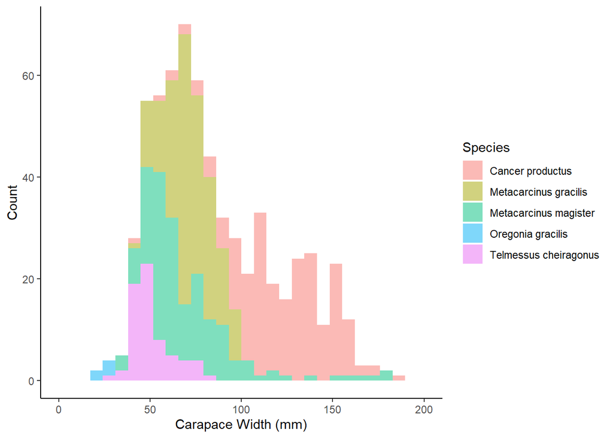

```r
crab %>%
  ggplot(aes(x=carapace_width_mm, fill=species_scientific))+
  geom_histogram(alpha=0.5)+
  labs(x="Carapace Width (mm)", y="Count", fill="Species")+
  xlim(c(0,200))+
  theme_classic()
```

# Adding a new session to practice commiting to Github

```r
summary(crab$Year)
```

```
##    Min. 1st Qu.  Median    Mean 3rd Qu.    Max.
##    2017    2017    2018    2018    2019    2019
```

```r
#further changes for github purposes
```